# Correspondence Analysis (CA) for textual data analysis

Denaldo Lapi, Samy Chouti, Franscesco Aristei

24 April 2022

```r
# delete R objects left in memory
rm(list = ls())
```

```r
# install needed packages
#install.packages(c("FactoMineR", "factoextra", "gplots", "corrplot", "gridExtra"))
```

```r
# load libraries
library(FactoMineR) # for CA
library(factoextra) # for ggplot visualizations
```

## Exploratory data analysis

```r
# Read the dataset
ca_data<-read.table("words_english.txt",header=TRUE,row.names=1)
```

```r
# check the dimensions of the frequency table
dim(ca_data)
```

```
[1] 274  60
```

As we will briefly see, the dataset is composed by 60 words (columns) and 274 answers/respondents.

```r
# inspect the dataset
head(ca_data) # first rows
```

|  | air | area | baggage | bar | bathrooms | beds | better | bigger | breakfast | cabins | cars | class | clean | cleaner | cleanliness | cold | comfort | comfortable | compartment | conditioning | crew | dining | dinner | door | english | food | high | insulation | larger | … |
| --- | --- | --- | --- | --- | --- | --- | --- | --- | --- | --- | --- | --- | --- | --- | --- | --- | --- | --- | --- | --- | --- | --- | --- | --- | --- | --- | --- | --- | --- | --- |
| 2609 | 0 | 0 | 1 | 0 | 0 | 0 | 0 | 0 | 0 | 1 | 0 | 0 | 0 | 0 | 0 | 0 | 0 | 0 | 0 | 0 | 0 | 0 | 0 | 0 | 0 | 0 | 0 | 0 | 0 | … |
| 2612 | 0 | 0 | 0 | 0 | 0 | 0 | 0 | 0 | 0 | 0 | 0 | 0 | 0 | 0 | 0 | 0 | 0 | 0 | 0 | 0 | 0 | 0 | 0 | 0 | 0 | 0 | 0 | 0 | 0 | … |
| 2616 | 0 | 0 | 0 | 0 | 0 | 0 | 0 | 0 | 0 | 0 | 0 | 0 | 0 | 0 | 0 | 0 | 0 | 0 | 0 | 0 | 0 | 0 | 0 | 0 | 0 | 0 | 0 | 0 | 0 | … |
| 2620 | 0 | 0 | 0 | 0 | 0 | 0 | 0 | 0 | 0 | 0 | 1 | 0 | 0 | 0 | 0 | 0 | 0 | 0 | 0 | 0 | 0 | 0 | 0 | 0 | 0 | 0 | 0 | 0 | 0 | … |
| 2625 | 0 | 0 | 0 | 0 | 0 | 0 | 0 | 0 | 0 | 2 | 0 | 0 | 0 | 0 | 0 | 0 | 0 | 0 | 0 | 0 | 0 | 0 | 0 | 0 | 0 | 0 | 0 | 0 | 0 | … |
| 2627 | 0 | 0 | 0 | 0 | 0 | 1 | 0 | 0 | 0 | 1 | 0 | 0 | 0 | 0 | 0 | 0 | 0 | 0 | 0 | 0 | 0 | 0 | 0 | 0 | 0 | 0 | 0 | 0 | 2 | … |

Let’s see a brief summary of the main statistics of the dataset:

```r
#summary(ca_data) # output too long to visualize
```

The data corresponds a survey conducted by a railway company to know the opinion and satisfaction of their passengers concerning high-quality night rail service. Passengers were asked to rate their satisfaction about 14 different aspects related to comfort (general, cabin, bed, seat), cleanliness (common areas, cabin, toilet), staff (welcome attention, trip attention, language skills) and others (cabin room, air conditioning, punctuality, general aspects). Each aspect was scored on a 11 point Likert scale from 0 (very bad) to 10 (excellent).

Additionally, an openended question was added to the questionnaire asking for the aspects that should be improved. This question required free and spontaneous answers in English.

Respondents × words *frequency table* (the table we read from the *.csv* file) was built following the classical preprocessing steps. Stop words were used and lemmatization from plural to singular form was performed.

Only the words used at least 5 times among all the answers were kept. Thus, 60 distinct words and 829 occurrences were kept for 274 respondents.

## CA

Let’s now apply CA to the given frequency table

```r
res.ca <- CA(ca_data, graph = FALSE) # don't show CA graph
```

Due to the high number of row and column points , the CA graph (factor map) is obviously very difficult to interpret because of many overlapping, that’s why we’ll try to visualize the result of the CA in a smarter way.

At first, let’s see a summary of the performed CA to obtain some first insights:

```r
summary(res.ca)
```

```
Call:
CA(X = ca_data, graph = FALSE)

The chi square of independence between the two variables is equal to 17042.78 (p-value =  1.529509e-07 ).

Eigenvalues
                       Dim.1   Dim.2   Dim.3   Dim.4   Dim.5   Dim.6   Dim.7   Dim.8   Dim.9  Dim.10  Dim.11  Dim.12  Dim.13  Dim.14
Variance               0.725   0.668   0.640   0.632   0.612   0.601   0.584   0.580   0.550   0.540   0.534   0.524   0.522   0.513
% of var.              3.526   3.251   3.116   3.074   2.978   2.926   2.843   2.819   2.677   2.625   2.598   2.548   2.538   2.494
Cumulative % of var.   3.526   6.777   9.892  12.966  15.944  18.870  21.712  24.532  27.209  29.834  32.432  34.981  37.518  40.012
                      Dim.15  Dim.16  Dim.17  Dim.18  Dim.19  Dim.20  Dim.21  Dim.22  Dim.23  Dim.24  Dim.25  Dim.26  Dim.27  Dim.28
Variance               0.507   0.480   0.472   0.462   0.443   0.440   0.420   0.411   0.395   0.378   0.373   0.358   0.353   0.346
% of var.              2.464   2.333   2.298   2.247   2.156   2.143   2.043   2.000   1.921   1.836   1.816   1.742   1.719   1.684
Cumulative % of var.  42.476  44.809  47.107  49.354  51.511  53.653  55.697  57.697  59.618  61.454  63.271  65.012  66.731  68.415
                      Dim.29  Dim.30  Dim.31  Dim.32  Dim.33  Dim.34  Dim.35  Dim.36  Dim.37  Dim.38  Dim.39  Dim.40  Dim.41  Dim.42
Variance               0.332   0.328   0.317   0.313   0.301   0.296   0.281   0.270   0.262   0.248   0.247   0.239   0.233   0.224
% of var.              1.615   1.597   1.540   1.521   1.463   1.441   1.366   1.311   1.275   1.205   1.200   1.161   1.134   1.088
Cumulative % of var.  70.030  71.627  73.167  74.688  76.151  77.592  78.958  80.269  81.544  82.749  83.949  85.111  86.245  87.332
                      Dim.43  Dim.44  Dim.45  Dim.46  Dim.47  Dim.48  Dim.49  Dim.50  Dim.51  Dim.52  Dim.53  Dim.54  Dim.55  Dim.56
Variance               0.213   0.204   0.198   0.196   0.178   0.174   0.167   0.162   0.158   0.156   0.144   0.126   0.122   0.113
% of var.              1.037   0.993   0.963   0.951   0.867   0.847   0.811   0.788   0.767   0.757   0.699   0.613   0.592   0.549
Cumulative % of var.  88.370  89.363  90.326  91.277  92.144  92.991  93.802  94.591  95.358  96.115  96.814  97.427  98.020  98.568
                      Dim.57  Dim.58  Dim.59
Variance               0.107   0.102   0.085
% of var.              0.521   0.495   0.415
Cumulative % of var.  99.089  99.585 100.000

Rows (the 10 first)
            Iner*1000     Dim.1     ctr    cos2     Dim.2     ctr    cos2     Dim.3     ctr    cos2
2609      |    53.217 |  -0.308   0.063   0.009 |  -0.040   0.001   0.000 |  -0.962   0.697   0.084 |
2612      |    46.413 |  -0.163   0.004   0.001 |  -0.374   0.025   0.004 |   0.104   0.002   0.000 |
2616      |    23.809 |  -0.329   0.054   0.016 |   0.030   0.000   0.000 |  -0.548   0.170   0.046 |
2620      |    75.717 |  -0.268   0.012   0.001 |   0.380   0.026   0.002 |   0.747   0.105   0.009 |
2625      |    32.481 |  -0.340   0.096   0.021 |  -0.055   0.003   0.001 |  -0.688   0.446   0.088 |
2627      |   153.270 |  -0.429   0.122   0.006 |  -0.473   0.162   0.007 |  -0.330   0.082   0.003 |
2630      |    30.044 |  -0.394   0.026   0.006 |  -0.446   0.036   0.008 |   0.250   0.012   0.003 |
2636      |    45.207 |  -0.279   0.026   0.004 |  -0.326   0.038   0.006 |   0.368   0.051   0.007 |
2637      |    30.044 |  -0.394   0.026   0.006 |  -0.446   0.036   0.008 |   0.250   0.012   0.003 |
2638      |    46.413 |  -0.422   0.030   0.005 |  -0.493   0.044   0.006 |   0.184   0.006   0.001 |

Columns (the 10 first)
            Iner*1000     Dim.1     ctr    cos2     Dim.2     ctr    cos2     Dim.3     ctr    cos2
air       |   371.369 |  -0.127   0.075   0.001 |  -0.331   0.554   0.010 |   0.886   4.136   0.071 |
area      |   222.849 |  -0.149   0.026   0.001 |  -0.415   0.218   0.007 |  -0.072   0.007   0.000 |
baggage   |   295.540 |  -0.223   0.050   0.001 |   0.098   0.010   0.000 |  -1.417   2.270   0.049 |
bar       |   243.709 |  -0.117   0.039   0.001 |  -0.059   0.011   0.000 |  -0.443   0.629   0.017 |
bathrooms |   483.058 |  -0.115   0.046   0.001 |  -0.131   0.065   0.001 |   0.441   0.769   0.010 |
beds      |   321.494 |  -0.359   0.451   0.010 |  -0.403   0.615   0.013 |   0.147   0.086   0.002 |
better    |   214.004 |  -0.262   0.126   0.004 |  -0.439   0.383   0.012 |   0.669   0.926   0.028 |
bigger    |   329.372 |  -0.475   0.413   0.009 |  -0.570   0.646   0.013 |   1.491   4.607   0.090 |
breakfast |   247.302 |  -0.037   0.001   0.000 |  -0.049   0.002   0.000 |  -0.915   0.789   0.020 |
cabins    |   264.022 |  -0.232   0.672   0.018 |  -0.158   0.337   0.009 |  -0.543   4.169   0.101 |
```

From the above summary, we can see that the CA method created 59 dimensions: this number corresponds to the number of columns (i.e. words) minus 1.

```r
# obtained  CA object
res.ca
```

```
**Results of the Correspondence Analysis (CA)**
The row variable has  274  categories; the column variable has 60 categories
The chi square of independence between the two variables is equal to 17042.78 (p-value =  1.529509e-07 ).
*The results are available in the following objects:

   name              description
1  "$eig"            "eigenvalues"
2  "$col"            "results for the columns"
3  "$col$coord"      "coord. for the columns"
4  "$col$cos2"       "cos2 for the columns"
5  "$col$contrib"    "contributions of the columns"
6  "$row"            "results for the rows"
7  "$row$coord"      "coord. for the rows"
8  "$row$cos2"       "cos2 for the rows"
9  "$row$contrib"    "contributions of the rows"
10 "$call"           "summary called parameters"
11 "$call$marge.col" "weights of the columns"
12 "$call$marge.row" "weights of the rows"
```

## Interpretation and visualizations

Let’s now analyze in details the outputs of the CA.

### Eigenvalues

The first aspect we typically look at in FA methods are eigenvalues, i.e. we try to understand how the newly created axes/dimensions are able to capture the deviation from independence, i.e. how the overall inertia of our cloud of points is explained by the new axes.

```r
# eigenvalues and explained inertia
res.ca$eig
```

```
       eigenvalue percentage of variance cumulative percentage of variance
dim 1  0.72481150              3.5256501                          3.525650
dim 2  0.66836172              3.2510653                          6.776715
dim 3  0.64049491              3.1155148                          9.892230
dim 4  0.63191568              3.0737834                         12.966014
dim 5  0.61224035              2.9780780                         15.944092
dim 6  0.60146992              2.9256882                         18.869780
dim 7  0.58441009              2.8427053                         21.712485
dim 8  0.57962737              2.8194410                         24.531926
dim 9  0.55034941              2.6770263                         27.208952
dim 10 0.53969884              2.6252195                         29.834172
dim 11 0.53409947              2.5979828                         32.432155
dim 12 0.52392656              2.5484994                         34.980654
dim 13 0.52171089              2.5377219                         37.518376
dim 14 0.51264026              2.4936003                         40.011976
dim 15 0.50655857              2.4640175                         42.475994
dim 16 0.47958064              2.3327907                         44.808785
dim 17 0.47247751              2.2982394                         47.107024
dim 18 0.46200675              2.2473073                         49.354331
dim 19 0.44332470              2.1564334                         51.510765
dim 20 0.44046228              2.1425100                         53.653275
dim 21 0.42010666              2.0434956                         55.696770
dim 22 0.41126028              2.0004647                         57.697235
dim 23 0.39486949              1.9207362                         59.617971
dim 24 0.37754114              1.8364471                         61.454418
dim 25 0.37341205              1.8163622                         63.270780
dim 26 0.35802733              1.7415274                         65.012308
dim 27 0.35332927              1.7186749                         66.730983
dim 28 0.34622280              1.6841074                         68.415090
dim 29 0.33199115              1.6148814                         70.029972
dim 30 0.32837575              1.5972953                         71.627267
dim 31 0.31656269              1.5398338                         73.167101
dim 32 0.31271179              1.5211022                         74.688203
dim 33 0.30067890              1.4625714                         76.150774
dim 34 0.29629270              1.4412359                         77.592010
dim 35 0.28089070              1.3663171                         78.958327
dim 36 0.26951377              1.3109770                         80.269304
dim 37 0.26209687              1.2748996                         81.544204
dim 38 0.24771626              1.2049489                         82.749153
dim 39 0.24675174              1.2002573                         83.949410
dim 40 0.23874938              1.1613320                         85.110742
dim 41 0.23311670              1.1339333                         86.244675
dim 42 0.22360180              1.0876507                         87.332326
dim 43 0.21326545              1.0373723                         88.369698
dim 44 0.20418575              0.9932065                         89.362905
dim 45 0.19794481              0.9628492                         90.325754
dim 46 0.19553582              0.9511313                         91.276885
dim 47 0.17832602              0.8674188                         92.144304
dim 48 0.17405607              0.8466488                         92.990953
dim 49 0.16680848              0.8113949                         93.802348
dim 50 0.16203865              0.7881933                         94.590541
dim 51 0.15771005              0.7671380                         95.357679
dim 52 0.15559795              0.7568643                         96.114543
dim 53 0.14379305              0.6994425                         96.813986
dim 54 0.12607643              0.6132648                         97.427251
dim 55 0.12176270              0.5922818                         98.019532
dim 56 0.11278652              0.5486196                         98.568152
dim 57 0.10716533              0.5212769                         99.089429
dim 58 0.10177833              0.4950733                         99.584502
dim 59 0.08541903              0.4154979                        100.000000
```

We can notice pretty large eigenvalues in the first dimensions: this indicates a quite strong association between words and respondents.

#### Scree Plot

Let’s graphically visualize the variance explained by the first 10 dimensions by means of a Scree Plot

```r
?fviz_screeplot
```

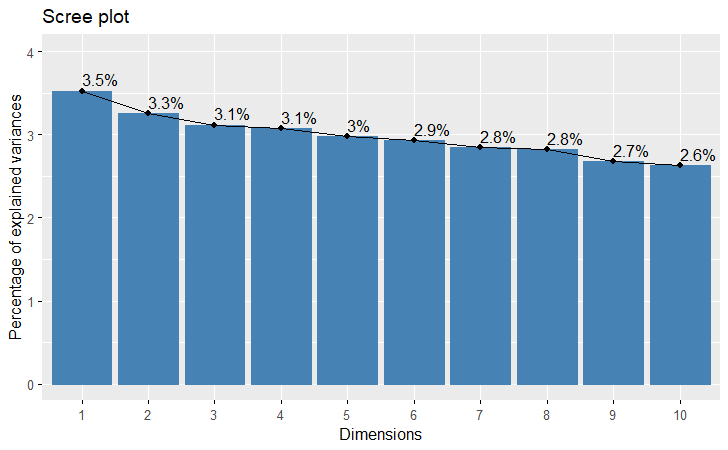

```r
fviz_screeplot(res.ca, addlabels = TRUE, ylim = c(0, 4), ggtheme = theme_get())
```

- **Which percentage of variability is explained by the first two dimensions?**  
  From the graph above and from the values seen before, we can see that the first 2 dimensions explain 6.78% of the variability of the entire cloud of points.

  Since the performed CA builds 59 dimensions, as expected the inertia is spread along all the components.

  This means that in order to do a complete analysis, we’ll need to take into consideration also the other axes, besides the first 2: for instance we can see that the variance captured by the 3rd and 4th dimensions is around 6.2%, which is still a pretty high value, compared to the one of the 1st factorial plane.

### Simultaneous representation of respondents and words

Let’s build some meaningful plots, since the full CA plot contains lots of overlapping points.

The function fviz_ca_biplot() of the package “factoextra” or the function plot.CA() of “FactoMineR” can be used to draw the biplot of rows and columns variables, i.e. to provide a simultaneous representation of rows and columns.

```r
?plot.CA
```

```r
?fviz_ca_biplot # provides ggplot-based elegant visualizations of CA outputs
```

To better render the graph, we limit the number of displayed labels by visualizing only the 30 words contributing more to the first factorial plane, and we put the labels only on the words, while we plot only the “point” shape for the repsondents.

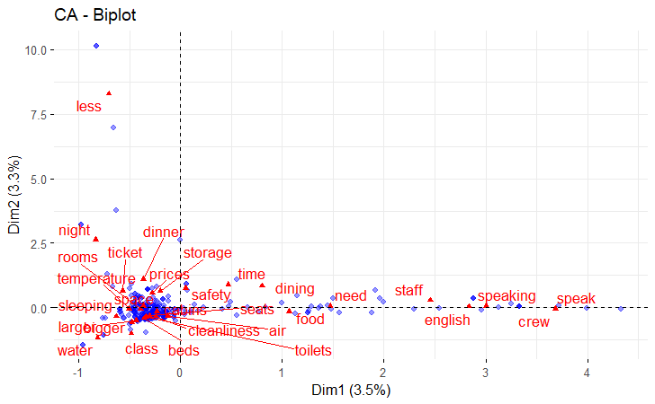

```r
options(ggrepel.max.overlaps =Inf) # max number of allowed overlaps

fviz_ca_biplot(res.ca, alpha.row = 0.4, select.col=list(contrib=30), geom.row = c("point"), repel = TRUE) # repel avoids text overlapping
```

Rows are represented as blue points and columns as red triangles. The distance between any row points or column points gives a measure of their similarity (or dissimilarity).

Row points (i.e. passengers) with similar profile (i.e. using common words in their answers) are closed on the factor map. The same holds true for column points, i.e. for “similar” words.

We can see that many points are not very well represented by the 1st factorial plane since very close to the origin, that’s why we’ll take into consideration also the 3rd and 4th axes, in order to obtain more complete interpretations.

Let’s now analyze separately rows and columns in order to study the similarities among words and passengers.

### Column analysis

```r
#res.ca$col
# Output to long to visualize
```

```r
# coordinates of the column points (i.e. words) in the new dimensions
head(res.ca$col$coord)
```

```
               Dim 1       Dim 2       Dim 3      Dim 4       Dim 5
air       -0.1267811 -0.33109243  0.88560479 -1.5424847  0.22475649
area      -0.1487693 -0.41498786 -0.07156733  0.7394871  0.76572734
baggage   -0.2228909  0.09782794 -1.41739490  0.5431048 -0.39624549
bar       -0.1171376 -0.05900065 -0.44314297  0.4167596  0.03765056
bathrooms -0.1149558 -0.13075010  0.44094147  2.4384030 -1.24206376
beds      -0.3592653 -0.40275288  0.14734105  0.6126579 -0.50693946
```

```r
# contribution to the CA axes
head(res.ca$col$contrib)
```

```
               Dim 1      Dim 2      Dim 3      Dim 4       Dim 5
air       0.07490101 0.55397533 4.13587806 12.7170420 0.278680143
area      0.02578371 0.21757186 0.00675239  0.7307109 0.808667269
baggage   0.04960854 0.01036361 2.27019293  0.3378352 0.185610887
bar       0.03882055 0.01068062 0.62873327  0.5636460 0.004748051
bathrooms 0.04618505 0.06479437 0.76897277 23.8350793 6.383084583
beds      0.45109742 0.61479526 0.08586113  1.5046717 1.063298046
```

```r
# quality of representation
head(res.ca$col$cos2)
```

```
                 Dim 1        Dim 2        Dim 3       Dim 4        Dim 5
air       0.0014618648 0.0099700292 0.0713309243 0.216391239 0.0045943324
area      0.0008386109 0.0065253584 0.0001940722 0.020720241 0.0222168194
baggage   0.0012166483 0.0002343722 0.0491996457 0.007223497 0.0038451113
bar       0.0011545562 0.0002929114 0.0165238204 0.014614834 0.0001192795
bathrooms 0.0006929900 0.0008964979 0.0101959360 0.311800052 0.0809008341
beds      0.0101700477 0.0127811418 0.0017105661 0.029575251 0.0202490444
```

#### Similarities between words

In order to interpret the similarities among words, let’s first plot them on the first factorial plane

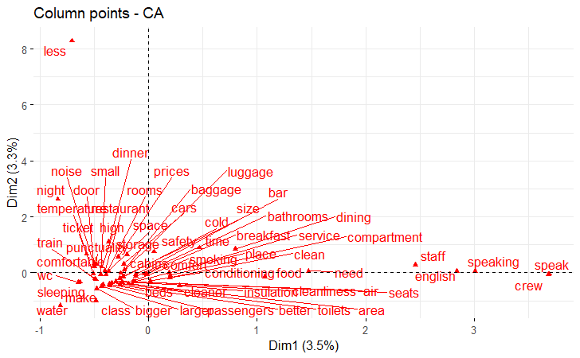

```r
options(ggrepel.max.overlaps =Inf) # max number of allowed overlaps
# visualize only col points
fviz_ca_col(res.ca, repel = TRUE)
```

The above plot shows the relationships between words: words with a similar profile are grouped together. while negatively correlated words are positioned on opposite sides of the plot origin (opposed quadrants).

The distance between the points and the origin measures the quality of the column points on the factor map. Column points that are away from the origin are well represented on the factor map. What we can see, in this case, is that many points are very closed to the origin and so we’ll need to look also at the other axes.

To better visualize the graph, we select only the 30 words that contribute more to the first factorial plane:

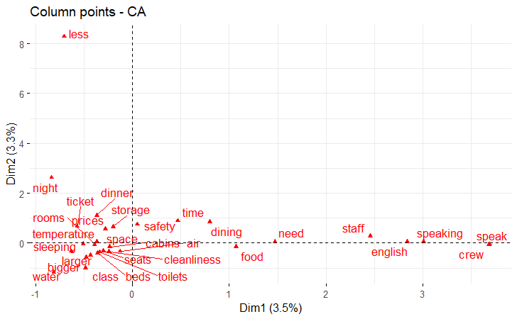

```r
options(ggrepel.max.overlaps =50)
fviz_ca_col(res.ca,  select.col=list(contrib=30), repel = TRUE, geom=c("point", "text"))
```

The above plot shows how the first factorial plane captures the variance in the column points (i.e. the words), and it also shows the relationships between the words.

What we can see is:

- the *1st axes* separates (on the right) words regarding the staff of the railway company from the rest of the words. Indeed on the right of the plot we have a cluster of words such as “staff”, “english”, “speaking”, “crew”, “speak”, which are all related to the staff and, in particular, to their language skills.
- While on the left side of the axes we have words related to other aspects of the quality of the night-rail service of the company, such as words related to “comfort” (“seats”, “cabins”, “beds”), and also to “cleanliness” (“cleanliness”, “toilets”)
- the 2nd axes clearly separates the word “less” (with very high coordinate value) from the rest of the words. Also the word “night” is pretty far from the others. For what regards the other words, almost all of them have very small coordinate value in the 2nd axes.
- We can identify other groups of similar words. For instance, we can spot some words related to food, which includes words such as “need”, “food”, “dining”, grouped together according to the 1st dimension. Also the words “larger”, “bigger”, seats”, “space” clearly identify a group related to a dimensional aspect. Another interesting similarity is the one among the words “prices”, “ticket”.
- However, the groups we identified around the origin of the axes are not clearly understandable, since the points are very closed to the origin. The only clearly identifiable groups of similar words in this 1st factorial plane are the one including words related to the staff, and the one regarding the “food” aspect.

That’s why it may be useful to study word similarities also by looking at the biplot with the 3rd and 4th axes, which still captures more than 6% of the overall variance:

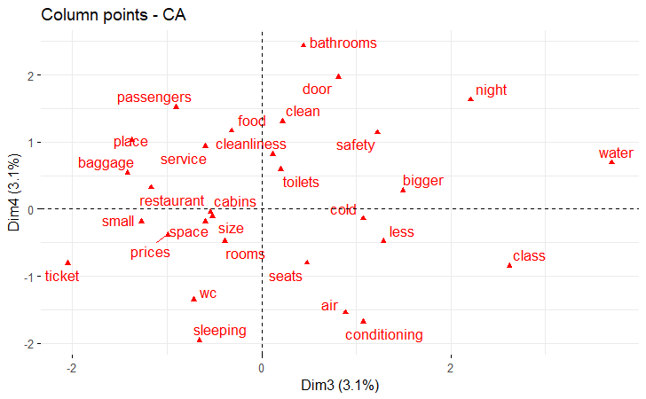

```r
fviz_ca_col(res.ca, axes = c(3,4), select.col=list(contrib=30), repel = TRUE)
```

What we can see is:

- The 3rd axes creates clusters of similar words depending on the quality aspect of the railway service they are related to: for instance, we can clearly see the words “conditioning”, “air”, cold” visualized very close to each other (very similar coordinate value on the 3rd axes), and we know they are related to the “air conditioning” aspect.

  Also words related to “comfort” are close to each other: “size”, “space”, “rooms”. In particular, notice that all these words are related to dimension features.

  In the lower part of the 3rd axes ( with negative coordinates) we have words related to economical aspects, in particular the words “prices” and “ticket”.
- By focusing on the 4th axes, we can notice other clusters of words, such as the words “cleanliness”, “clean”, “toilets”, all related to the “cleanliness” aspect.
- A very interesting property of this plot, related to the grouping of the ‘similar’ words, is related to the separation between the words “sleeping” and “bathrooms” which are in opposite sides w.r.t. the 4th axes: this indicates a strong distance among the 2 words which, as we may expect, do not usually appear together.

### Row analysis

Let’s now briefly analyze separately the row points, i.e. the different passengers’ answers.

```r
#head(res.ca$row)
# Output to long to visualize
```

```r
# coordinates of the row points into the newly created dimensions
head(res.ca$row$coord) # coordinates of the first 6 row points
```

```
          Dim 1       Dim 2      Dim 3       Dim 4      Dim 5
2609 -0.3083601 -0.04046626 -0.9617285  0.06531729 -0.4269296
2612 -0.1629237 -0.37404446  0.1038214  0.60227132  0.8765378
2616 -0.3291574  0.02963344 -0.5483127  0.04411282  0.2888345
2620 -0.2684093  0.38011708  0.7471559 -0.50655673  0.2296604
2625 -0.3398625 -0.05451124 -0.6883827 -0.12499478 -0.4395632
2627 -0.4286423 -0.47337112 -0.3297875  0.56028918 -0.5696685
```

```r
# # contribution to the CA axes
head(res.ca$row$contrib)
```

[output not shown]

#### Similarities between respondents

In order to interpret the similarities among respondents (i.e. rows), let’s plot them on the first factorial plane:

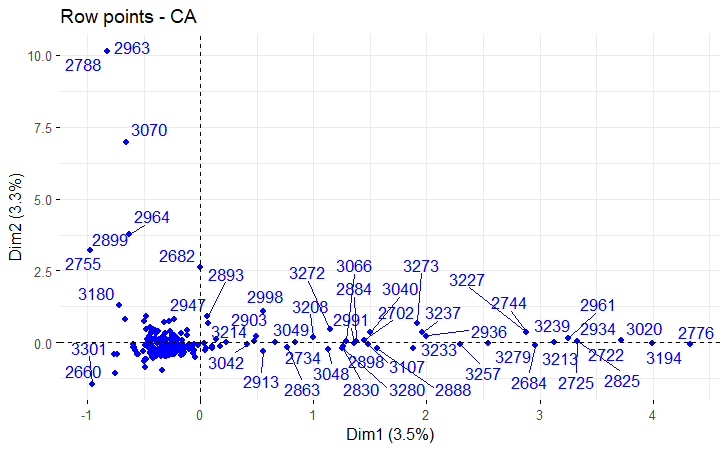

```r
# visualize only col points
fviz_ca_row(res.ca, repel = TRUE)
```

The above plot shows the relationships between the participants of the survey: in particular, the participants with a similar profile, i.e. suggesting similar improvements to the railway company, are grouped together; while negatively correlated participants are positioned on opposite sides of the plot origin (opposed quadrants).

The distance between the points and the origin measures the quality of the points on the factor map. Row points that are away from the origin are well represented on the factor map.

To better visualize the graph, we select only the 30 participants that contribute more to the first factorial plane:

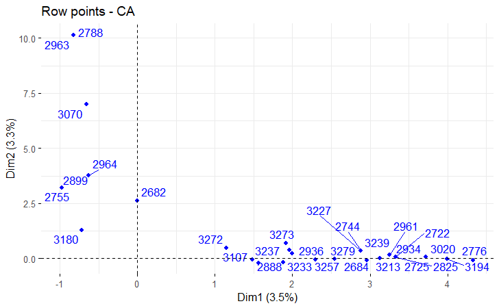

```r
fviz_ca_row(res.ca,  select.row=list(contrib=30), repel = TRUE)
```

In order to find some similarities among the participants, we should add to the plot also the words: this will allow to group participants depending on the words they use inside their answers; this means that we’ll find similar participants, according to the words they used in their answers to the open-ended question.

In order to do that, let’s visualize side by side the 2 biplots (we could plot the biplot with the simultaneous representation of rows and columns, but it’s not so clear due to the high number of overlapping), by considering only the most contributing points :

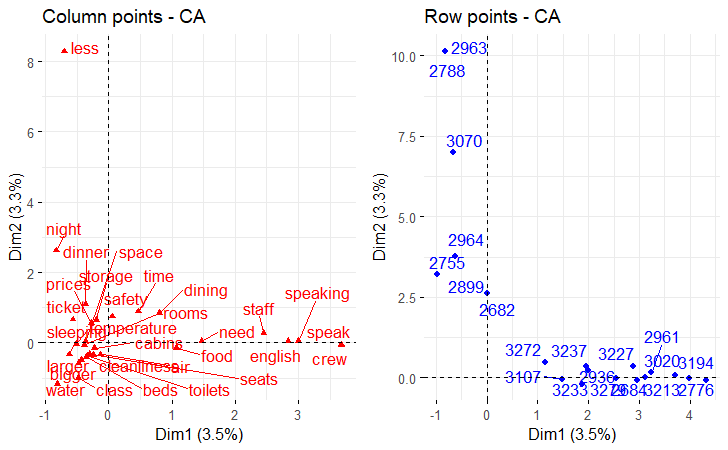

```r
library(gridExtra) # to create subplots
g1 <- fviz_ca_col(res.ca,  select.col=list(contrib=30), repel = TRUE)
g2 <-fviz_ca_row(res.ca,  select.row=list(contrib=20), repel = TRUE)
grid.arrange(g1,g2,nrow=1, ncol=2)
```

The main similarities among participants we can spot from the above plot are (pay attention to the different scales of the axes between the 2 plots):

- Participants 2788 and 2963 are closely related to each other in the position of the word “less”, this means that their answers include that word.
- In the right side of the 1st axes, we have a group of participants who suggested to the company improvements related to the “staff”: indeed these row points (such as 2776, 3194, 3020, 2961,…) are positioned in the same zone where are located also words related to the “staff” aspect.
- We can identify, for instance, a group of users (composed by 3107, 3272, 3233) which suggested improvements related to the “food” aspect.
- Participants 2682, 2899 used the words “night” and “dinner” in their free answers.

We can repeat the same analysis by considering the biplots with the 3rd and 4th axes.:

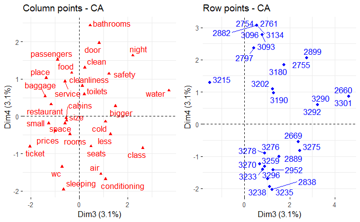

```r
g1 <- fviz_ca_col(res.ca, axes = c(3,4), select.col=list(contrib=30), repel = TRUE)
g2 <-fviz_ca_row(res.ca, axes = c(3,4),  select.row=list(contrib=30), repel = TRUE)
grid.arrange(g1,g2,nrow=1, ncol=2)
```

We can spot the following similarities:

### Best represented words in the first factorial plane

Best represented words in the first factorial plane are those with the highest quality of representation, i.e. the words with the higher values of the squared cosine (cos2).

We know that the values of the cos2 of each row or column are comprised between 0 and 1: therefore the sum of the cos2 for row/column points over all the CA dimensions is equal to one.

Hence, we can say that the quality of representation of a word/column in n dimensions is simply the sum of the squared cosine of that column over the n considered dimensions.

In our case, if a word is well represented by the first two dimensions, the sum of the cos2 is closed to one.

Let’s create a bar plot of the words cos2 using the function fviz_cos2() of the faxtoextra package:

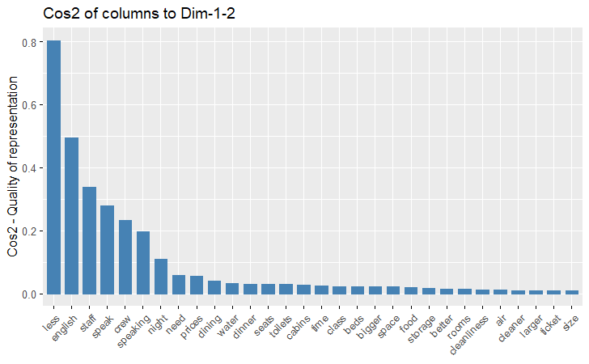

```r
# Cos2 of rows on Dim.1 and Dim.2
fviz_cos2(res.ca, choice = "col", axes = 1:2, repel=TRUE, top=30, ggtheme=theme_get()) # show only top 15
```

The above bar plot shows, in descending order, the quality of representation of columns (i.e. words) on the first 2 dimensions.

We can easily see that the best represented words are, in order: “less”, “english”, “staff”, “speak”, “crew”, “speaking”, …

Basically, these are the words related to the “staff” aspect (except for “less”) that in the 1st factorial plane are more distant from the origin.

### Stability of the representation

When deciding to analyze text data we should decide what is the minimum word count starting from which you choose to include words.

Typically, we should change the minimum threshold for the word frequency in order to verify the stability of the obtained representation, i.e. to see if we obtain a similar biplot.

The analysis we performed until now is done by considering only words used at least 5 times among all the answers.

Let’s now repeat the CA by taking into consideration words appearing at least 10 times.

At first, let’s built our new frequency table:

```r
# just transpose the dataframe
ca_data_t = t(ca_data)

#Consider words that are cited at least 10 times
ca_data10_t = ca_data_t[apply(ca_data_t, 1, sum)>=10,]
ca_data10 = t(ca_data10_t)

# obtain a dataframe
ca_data10 = data.frame(ca_data10)
```

```r
# check the dimensions of the frequency table
dim(ca_data10)
```

```
[1] 274  26
```

```r
ca_data10
```

|  | air | bar | bathrooms | beds | better | bigger | cabins | cars | cleaner | cleanliness | cold | comfort | conditioning | english | luggage | prices | rooms | seats | service | size | smoking | space | staff | storage | temperature | toilets |
| --- | --- | --- | --- | --- | --- | --- | --- | --- | --- | --- | --- | --- | --- | --- | --- | --- | --- | --- | --- | --- | --- | --- | --- | --- | --- | --- |
| 2609 | 0 | 0 | 0 | 0 | 0 | 0 | 1 | 0 | 0 | 0 | 0 | 0 | 0 | 0 | 0 | 0 | 0 | 0 | 0 | 1 | 0 | 1 | 0 | 0 | 0 | 0 |
| 2612 | 0 | 0 | 0 | 0 | 0 | 0 | 0 | 0 | 0 | 0 | 0 | 0 | 0 | 0 | 0 | 0 | 0 | 0 | 0 | 0 | 1 | 0 | 0 | 0 | 0 | 0 |
| 2616 | 0 | 0 | 0 | 0 | 0 | 0 | 0 | 0 | 0 | 0 | 0 | 0 | 0 | 0 | 0 | 1 | 0 | 0 | 0 | 1 | 0 | 0 | 0 | 0 | 0 | 1 |
| 2620 | 0 | 0 | 0 | 0 | 0 | 0 | 0 | 1 | 0 | 0 | 0 | 0 | 0 | 0 | 0 | 0 | 0 | 0 | 0 | 0 | 0 | 0 | 0 | 0 | 0 | 0 |
| 2625 | 0 | 0 | 0 | 0 | 0 | 0 | 2 | 0 | 0 | 0 | 0 | 0 | 0 | 0 | 1 | 0 | 0 | 0 | 0 | 0 | 0 | 2 | 0 | 0 | 0 | 0 |
| 2627 | 0 | 0 | 0 | 1 | 0 | 0 | 1 | 0 | 0 | 0 | 0 | 0 | 0 | 0 | 0 | 0 | 0 | 0 | 0 | 0 | 0 | 0 | 0 | 0 | 0 | 0 |
| 2630 | 0 | 0 | 0 | 0 | 0 | 0 | 0 | 0 | 0 | 0 | 0 | 0 | 0 | 0 | 0 | 0 | 0 | 0 | 0 | 0 | 0 | 0 | 0 | 0 | 0 | 1 |
| 2636 | 0 | 0 | 1 | 1 | 0 | 0 | 0 | 0 | 0 | 0 | 0 | 0 | 0 | 0 | 0 | 0 | 0 | 0 | 0 | 0 | 0 | 0 | 0 | 0 | 0 | 0 |
| 2637 | 0 | 0 | 0 | 0 | 0 | 0 | 0 | 0 | 0 | 0 | 0 | 0 | 0 | 0 | 0 | 0 | 0 | 0 | 0 | 0 | 0 | 0 | 0 | 0 | 0 | 1 |
| 2638 | 0 | 0 | 0 | 1 | 0 | 0 | 0 | 0 | 0 | 0 | 0 | 0 | 0 | 0 | 0 | 0 | 0 | 0 | 0 | 0 | 0 | 0 | 0 | 0 | 0 | 0 |

[output cut: 264 more lines]

The new table will contain only 26 words.

Let’s now repeat the CA

```r
res.ca10 <- CA(ca_data10, graph = FALSE) # don't show CA graph
```

```r
summary(res.ca10)
```

```
Call:
CA(X = ca_data10, graph = FALSE)

The chi square of independence between the two variables is equal to 6453.081 (p-value =  0.02140187 ).

Eigenvalues
                       Dim.1   Dim.2   Dim.3   Dim.4   Dim.5   Dim.6   Dim.7   Dim.8   Dim.9  Dim.10  Dim.11  Dim.12  Dim.13  Dim.14
Variance               0.723   0.651   0.639   0.613   0.575   0.540   0.535   0.498   0.489   0.466   0.459   0.452   0.439   0.405
% of var.              6.948   6.254   6.137   5.892   5.521   5.188   5.140   4.783   4.695   4.477   4.410   4.346   4.216   3.892
Cumulative % of var.   6.948  13.201  19.338  25.230  30.751  35.939  41.079  45.862  50.557  55.034  59.444  63.790  68.007  71.898
                      Dim.15  Dim.16  Dim.17  Dim.18  Dim.19  Dim.20  Dim.21  Dim.22  Dim.23  Dim.24  Dim.25
Variance               0.391   0.362   0.338   0.326   0.309   0.274   0.215   0.204   0.192   0.173   0.142
% of var.              3.753   3.482   3.245   3.136   2.967   2.632   2.064   1.957   1.841   1.662   1.363
Cumulative % of var.  75.651  79.133  82.378  85.513  88.480  91.113  93.176  95.134  96.975  98.637 100.000

Rows (the 10 first)
              Iner*1000    Dim.1    ctr   cos2    Dim.2    ctr   cos2    Dim.3    ctr   cos2
2609        |    16.995 | -0.299  0.060  0.026 | -0.826  0.508  0.194 | -0.466  0.165  0.062 |
2612        |    46.006 | -0.118  0.003  0.000 |  0.570  0.080  0.011 |  0.724  0.132  0.018 |
2616        |    22.589 | -0.266  0.047  0.015 | -0.605  0.272  0.079 | -0.272  0.056  0.016 |
2620        |    75.310 | -0.440  0.043  0.004 |  1.279  0.405  0.035 |  0.001  0.000  0.000 |
2625        |    30.448 | -0.268  0.080  0.019 | -0.778  0.751  0.160 | -0.456  0.262  0.055 |
2627        |    27.250 | -0.251  0.028  0.007 | -0.751  0.279  0.067 |  0.267  0.036  0.008 |
2630        |    29.637 | -0.504  0.057  0.014 |  0.162  0.007  0.001 |  0.823  0.171  0.037 |
2636        |    44.393 |  0.146  0.009  0.002 | -0.846  0.355  0.052 |  2.515  3.194  0.459 |
2637        |    29.637 | -0.504  0.057  0.014 |  0.162  0.007  0.001 |  0.823  0.171  0.037 |
2638        |    46.006 | -0.308  0.021  0.003 | -0.652  0.105  0.015 |  0.897  0.203  0.028 |

Columns (the 10 first)
              Iner*1000     Dim.1     ctr    cos2     Dim.2     ctr    cos2     Dim.3     ctr    cos2
air         |   400.077 |  -0.632   2.493   0.045 |   1.981  27.232   0.443 |  -0.126   0.112   0.002 |
bar         |   308.435 |   0.243   0.224   0.005 |  -0.248   0.260   0.005 |   0.164   0.115   0.002 |
bathrooms   |   580.415 |   0.510   1.219   0.015 |  -0.839   3.666   0.041 |   3.302  57.828   0.636 |
beds        |   389.939 |  -0.262   0.322   0.006 |  -0.526   1.442   0.024 |   0.717   2.728   0.045 |
better      |   415.591 |  -0.568   0.790   0.014 |   0.779   1.653   0.026 |   0.493   0.674   0.010 |
bigger      |   439.834 |  -0.491   0.592   0.010 |   0.504   0.692   0.010 |   0.713   1.410   0.020 |
cabins      |   327.096 |  -0.165   0.458   0.010 |  -0.685   8.714   0.173 |  -0.291   1.600   0.031 |
cars        |   379.765 |  -0.374   0.405   0.008 |   1.032   3.428   0.059 |   0.001   0.000   0.000 |
cleaner     |   281.609 |  -0.272   0.182   0.005 |  -0.176   0.085   0.002 |   0.639   1.136   0.026 |
cleanliness |   392.742 |  -0.263   0.309   0.006 |   0.300   0.445   0.007 |   1.122   6.354   0.103 |
```

Now we have only 25 dimensions.

```r
# eigenvalues and explained inertia
res.ca$eig
```

[output not shown]

Again,the first eigenvalues have high values, indicating a quite strong association among words and participants.

Let’s visualize the biplot:

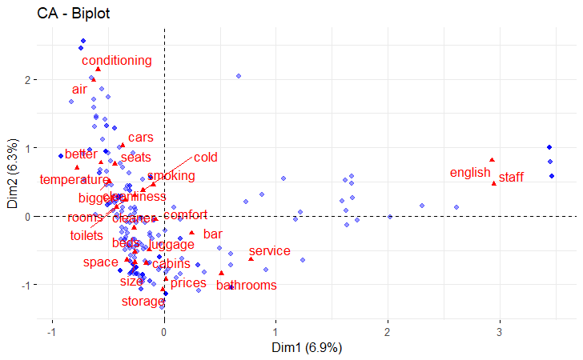

```r
fviz_ca_biplot(res.ca10, alpha.row = 0.4, select.col=list(contrib=30), geom.row = c("point"), repel = TRUE) # repel avoids text overlapping
```

In order to compare this plot with the one of the previous analysis, we put the plots one after the other: on the left we plot the biplot of the previous analysis, while on the right the new one:

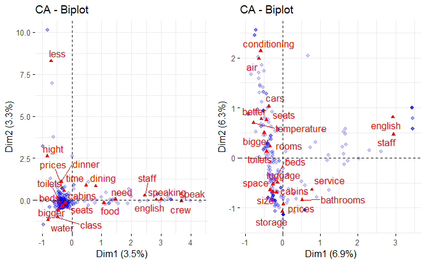

```r
g1<- fviz_ca_biplot(res.ca, alpha.row = 0.2, select.col=list(contrib=20), geom.row = c("point"), repel = TRUE) # repel avoids text overlapping
g2<-fviz_ca_biplot(res.ca10, alpha.row = 0.2, select.col=list(contrib=20), geom.row = c("point"), repel = TRUE) # repel avoids text overlapping
grid.arrange(g1,g2,nrow=1, ncol=2)
```

We can identify similar associations among words:

- even if the absolute word positioning changes (in the 2nd case the 1st factorial plane captures more than 13% of the overall variance), similar words are still closed to each other (e.g. “english and”staff”, “air” and “conditioning”, “size” and “space”